# DA5020.P1.Kruti.Bhopalkar

Group15_KRUTI_BHOPALKAR.PRACHI_SARDANA.JUNTING_LIU

2024-02-16

# Part 1: Answer the following questions.

## Question 1

Create a dataframe with 4 variables. The 4 variables should be doctor_type, doctor_lastname, location, AVG_Rating.

The variable doctor_type should contain 4 inputs (PCP, Psychiatrist, Surgeon, Anesthesia) The variable doctor_lastname should contain 4 inputs (Smith, Dame, Jones, Zayas) The variable location should contain 4 inputs (MA, ME, NH, VT) The variable AVG_Rating should contain 4 inputs (7,9,8,9) Print the dataframe and include a screenshot?

```r
# Loaded the required packages
library(ggplot2)
library(tibble)
library(dplyr)
library(readr)

# Creating a dataframe with the following variables
doctor_df <- data.frame(
  doctor_type = c("PCP","Psychiatrist", "Surgeon", "Anesthesia"),
  doctor_lastname = c("Smith", "Dame", "Jones", "Zayas"),
  location = c("MA", "ME", "NH", "VT"),
  AVG_Rating = c(7,9,8,9))

# Printing the dataframe
print(doctor_df)
```

```
##    doctor_type doctor_lastname location AVG_Rating
## 1          PCP           Smith       MA          7
## 2 Psychiatrist            Dame       ME          9
## 3      Surgeon           Jones       NH          8
## 4   Anesthesia           Zayas       VT          9
```

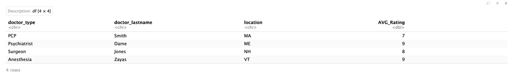

```r
# using Knitr include graphics to save the screenshot
knitr::include_graphics("C:/Users/sarda/Downloads/Practicum1_doctor_df.png")
```

## Question 2

Using the dataframe above… Select row 1 in column 2, what was selected? Select rows 2 through 4, what was selected? Select the last column, what was selected?

```r
# Select row1 in coloumn2
row1_col2 <- doctor_df[1,2]
print(row1_col2)
```

```
## [1] "Smith"
```

```r
# Selecting rows2 through 4
rows2_through4 <- doctor_df[2:4, ]
print(rows2_through4)
```

```
##    doctor_type doctor_lastname location AVG_Rating
## 2 Psychiatrist            Dame       ME          9
## 3      Surgeon           Jones       NH          8
## 4   Anesthesia           Zayas       VT          9
```

```r
# Selecting the last coloumn of doctor_df dataframe
last_col <- doctor_df[, ncol(doctor_df)]
print(last_col)
```

```
## [1] 7 9 8 9
```

## Question 3

Using the dataset Mtcars create a scatterplot showing the relations between any two variables of your choosing. Explain why you picked those variables. Each point should also be based on a color scheme of your choosing.

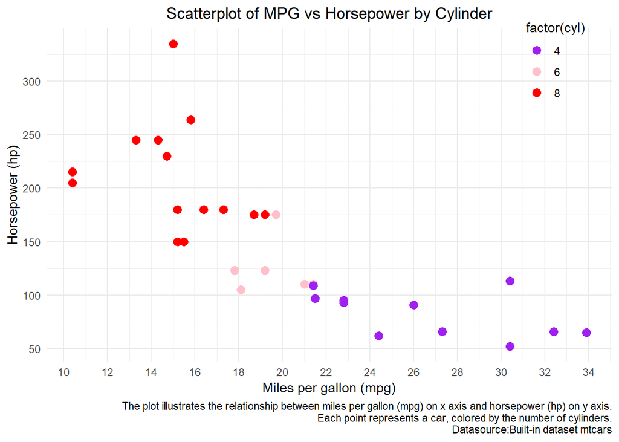

```r
# Loading the mtcars data
mtcars_data <- mtcars

# Creating the scatterplot of miles per gallon with horse power , factoring by cylinder
ggplot(mtcars_data, aes(x = mpg, y = hp, color = factor(cyl))) +
  geom_point(size = 3) +
  labs(x = "Miles per gallon (mpg)", y = "Horsepower (hp)",
       title = "Scatterplot of MPG vs Horsepower by Cylinder",
       caption="The plot illustrates the relationship between miles per gallon (mpg) on x axis and horsepower (hp) on y axis.\nEach point represents a car, colored by the number of cylinders.\n Datasource:Built-in dataset mtcars") +
  scale_color_manual(values = c("purple", "pink", "red")) +
  theme_minimal() +
  # Adjusting the legend position at the bottom
  theme(legend.position = c(0.9, 0.9)) +
  #  using hjust 0.5 to adjust the title to the center
  theme(plot.title = element_text(hjust = 0.5)) +
  # Setting scales for x axis and y axis by proper breaks
  scale_x_continuous(breaks = seq(10, 35, by = 2)) +
  scale_y_continuous(breaks = seq(50, 350, by = 50))
```

The scatterplot above illustrates the relationship between miles per gallon and horsepower since mpg is an important indicator of fuel efficiency aiming to improve the car performance and horsepower is the power that engine can produce which is a primary factor in measuring the vehicles performance.The number of cylinders in an engine impact both mpg and horsepower. Engines with more cylinders produce more power but are less fuel efficient as more cylinders generate more power and tend to have higher displacement , leading to more fuel consumption. Based on the plot, the Mpg and horsepower are related and their relationships vary with respect to the cylinder counts. The vehicles that have higher horsepower tend to have lower miles per gallon, particularly with greater number of cylinders. Based on the color schema of cylinders, their relationship varies.

## Question 4

Using the dataset MTcars perform a summary statistic on the dataset and calculate the pearson coefficient of the correlation R picking two variables of choice. Explain why you picked those variables and explain the purpose of a pearson coefficient.

```r
# Summary statistics of mtcars_data showing the data distribution of all variables in the data
summary(mtcars_data)
```

```
##       mpg             cyl             disp             hp
##  Min.   :10.40   Min.   :4.000   Min.   : 71.1   Min.   : 52.0
##  1st Qu.:15.43   1st Qu.:4.000   1st Qu.:120.8   1st Qu.: 96.5
##  Median :19.20   Median :6.000   Median :196.3   Median :123.0
##  Mean   :20.09   Mean   :6.188   Mean   :230.7   Mean   :146.7
##  3rd Qu.:22.80   3rd Qu.:8.000   3rd Qu.:326.0   3rd Qu.:180.0
##  Max.   :33.90   Max.   :8.000   Max.   :472.0   Max.   :335.0
##       drat             wt             qsec             vs
##  Min.   :2.760   Min.   :1.513   Min.   :14.50   Min.   :0.0000
##  1st Qu.:3.080   1st Qu.:2.581   1st Qu.:16.89   1st Qu.:0.0000
##  Median :3.695   Median :3.325   Median :17.71   Median :0.0000
##  Mean   :3.597   Mean   :3.217   Mean   :17.85   Mean   :0.4375
##  3rd Qu.:3.920   3rd Qu.:3.610   3rd Qu.:18.90   3rd Qu.:1.0000
##  Max.   :4.930   Max.   :5.424   Max.   :22.90   Max.   :1.0000
##        am              gear            carb
##  Min.   :0.0000   Min.   :3.000   Min.   :1.000
##  1st Qu.:0.0000   1st Qu.:3.000   1st Qu.:2.000
##  Median :0.0000   Median :4.000   Median :2.000
##  Mean   :0.4062   Mean   :3.688   Mean   :2.812
##  3rd Qu.:1.0000   3rd Qu.:4.000   3rd Qu.:4.000
##  Max.   :1.0000   Max.   :5.000   Max.   :8.000
```

```r
# Calculating the pearson correlation coefficient between mpg and weight
pearson_corr <- cor.test(mtcars_data$mpg, mtcars_data$wt, method = "pearson")
pearson_corr
```

```
##
##  Pearson's product-moment correlation
##
## data:  mtcars_data$mpg and mtcars_data$wt
## t = -9.559, df = 30, p-value = 1.294e-10
## alternative hypothesis: true correlation is not equal to 0
## 95 percent confidence interval:
##  -0.9338264 -0.7440872
## sample estimates:
##        cor
## -0.8676594
```

Calculated the summary statistics on mtcars dataset.The pearson coorelation cofficient is an important indicator which indicates the direction of relationship between the two variables. Calculating the correlation coefficient between two key variables miles per gallon and weight which are important in understanding the car performance. The variables are negatively correlated with each other indicating that higher the weight of the car , the lower is the fuel efficiency. i.e mpg(Miles per gallon).

# Part 2: Practicum Tasks

## Question 1

Load the New York State data, directly from the URL. This dataset includes the number of admissions to certified treatment programs aggregated by the program category, county of the program location, age group of client at admission, and the primary substance of abuse group

```r
# Loading the csv data through url
url <- "https://data.ny.gov/api/views/ngbt-9rwf/rows.csv"
NYC_data <- read.csv(url)
NYC_data
```

## Question 2

Evaluate the dataset to determine what data preparation steps are needed and perform them. At a minimum, ensure that you discuss the distribution of the data, outliers and prepare any helpful summary statistics to support your analysis.

```r
# Loading the structure of the data
str(NYC_data)
```

```
## 'data.frame':    99367 obs. of  7 variables:
##  $ Year                      : int  2007 2007 2007 2007 2007 2007 2007 2007 2007 2007 ...
##  $ County.of.Program.Location: chr  "Albany" "Albany" "Albany" "Albany" ...
##  $ Program.Category          : chr  "Crisis" "Crisis" "Crisis" "Crisis" ...
##  $ Service.Type              : chr  "Medical Managed Detoxification" "Medical Managed Detoxification" "Medical Managed Detoxification" "Medical Managed Detoxification" ...
##  $ Age.Group                 : chr  "Under 18" "18 through 24" "18 through 24" "18 through 24" ...
##  $ Primary.Substance.Group   : chr  "Heroin" "All Others" "Other Opioids" "Heroin" ...
##  $ Admissions                : int  4 2 6 132 35 8 1 11 276 135 ...
```

```r
# Loading the dimensions of the data
dim(NYC_data)
```

```
## [1] 99367     7
```

```r
# Looking at the data distribution of NYC data through summary function
summary(NYC_data)
```

```
##       Year      County.of.Program.Location Program.Category
##  Min.   :2007   Length:99367               Length:99367
##  1st Qu.:2010   Class :character           Class :character
##  Median :2014   Mode  :character           Mode  :character
##  Mean   :2014
##  3rd Qu.:2018
##  Max.   :2021
##  Service.Type        Age.Group         Primary.Substance.Group
##  Length:99367       Length:99367       Length:99367
##  Class :character   Class :character   Class :character
##  Mode  :character   Mode  :character   Mode  :character
##
##
##
##    Admissions
##  Min.   :   1.00
##  1st Qu.:   2.00
##  Median :   8.00
##  Mean   :  41.91
##  3rd Qu.:  28.00
##  Max.   :2861.00
```

```r
# Looking for missing values in the NYC data
missing_val <- colSums(is.na(NYC_data))

# If sum of missing values  = 0
if (sum(missing_val) == 0) {
  print("There are no missing values in the dataset.")
} else {
  # Otherwise, print the number of missing values per column
  print("There are missing values in the dataset.")
}
```

```
## [1] "There are no missing values in the dataset."
```

```r
# Creating an outliers function to find outliers in all the columns of the data
identify_outliers <- function(col) {
  # Checking for numeric columns in the data
  if(is.numeric(col)) {
    # Calculate the mean
    mean_val <- mean(col)
    # Calculate the standard deviation
    std_dev <- sd(col)
    # Calculate the z scores
    z_scores <- (col - mean_val) / std_dev
    # Identify the outliers where z scores is greater than the threshold 3
    outliers <- which(abs(z_scores) > 3)
    # Return outliers
    return(outliers)
  } else {
    # else return Null if coloumns are not numeric
    return(NULL)
  }
}


outliers_list <- lapply(NYC_data, identify_outliers)
# Looping over each column to find the outliers and count the total outliers
# Inititalizing the total outliers count to 0
total_outliers <- 0
for (x in seq_along(outliers_list)) {
  # Checking for any outliers if they exist
  if(length(outliers_list[[x]]) > 0) {
    num_outliers <- length(outliers_list[[x]])
    # Counting the total outliers
    total_outliers <- total_outliers + num_outliers
    # Printing the names of the coloumn that consist of outliers
    cat("Outliers in column", names(outliers_list)[x], ":", num_outliers, "\n")
  }
}
```

```
## Outliers in column Admissions : 1917
```

Used str to structure the data and checked the dimensions of the data using dim function which consist of 99367 observations of 7 variables. Using summary function to check the distribution of New York Sate data. Looking for any missing values in the NYC_data. Since there are no missing values in the data set, going ahead with identifying outliers. The total 1917 outliers in column Admissions were detected.

## Question 3

Structure the data relationally, at a minimum, you should have four tibbles or data frames as follows: • county which contains the name of all counties and their respective county code (which is the primary key). For example: county_code county_name AL Albany Note: ensure that your data frame does not contain duplicate counties and ensure that your dataframe contains all counties in the data.

```r
unique(NYC_data$County.of.Program.Location)
```

```
##  [1] "Albany"         "Allegany"       "Bronx"          "Broome"
##  [5] "Cattaraugus"    "Cayuga"         "Chautauqua"     "Chemung"
##  [9] "Chenango"       "Clinton"        "Columbia"       "Cortland"
## [13] "Delaware"       "Dutchess"       "Erie"           "Essex"
## [17] "Franklin"       "Fulton"         "Genesee"        "Greene"
## [21] "Herkimer"       "Jefferson"      "Kings"          "Lewis"
## [25] "Livingston"     "Madison"        "Monroe"         "Montgomery"
## [29] "Nassau"         "New York"       "Niagara"        "Oneida"
## [33] "Onondaga"       "Ontario"        "Orange"         "Orleans"
## [37] "Oswego"         "Otsego"         "Putnam"         "Queens"
## [41] "Rensselaer"     "Richmond"       "Rockland"       "Saint Lawrence"
## [45] "Saratoga"       "Schenectady"    "Schoharie"      "Schuyler"
## [49] "Seneca"         "Steuben"        "Suffolk"        "Sullivan"
## [53] "Tioga"          "Tompkins"       "Ulster"         "Warren"
## [57] "Washington"     "Wayne"          "Westchester"    "Wyoming"
## [61] "Yates"
```

```r
county <- tibble(county_code = c("AL","CA","CN","DE","FR","LE","MG","ON","OL","NY","SL","SY","SV","WR","AG","CY","CL","DU","FU","HE","LI","NA","OD","OS","RE","SA","SE","TI","WS","NY","CH","CO","ER","GE","JE","MA","NY","OT","OG","NY","SC","ST","TO","WA","BM","CM","CR","ES","GR","NY","MO","NI","OR","PU","RO","SH","SU","UL","WE","WY","YA"),
county_of_program_location = c("Albany","Cattaraugus","Chenango","Delaware","Franklin","Lewis","Montgomery","Oneida","Orleans","Queens","Saint Lawrence","Schuyler","Sullivan","Warren","Allegany","Cayuga","Clinton","Dutchess","Fulton","Herkimer","Livingston","Nassau","Onondaga","Oswego","Rensselaer","Saratoga","Seneca","Tioga","Washington","Bronx","Chautauqua","Columbia","Erie","Genesee","Jefferson","Madison","New York","Ontario","Otsego","Richmond","Schenectady","Steuben","Tompkins","Wayne","Broome","Chemung","Cortland","Essex","Greene","Kings","Monroe","Niagara","Orange","Putnam","Rockland","Schoharie","Suffolk","Ulster","Westchester","Wyoming","Yates"))

county <-unique(county)
head(county)
```

```
## # A tibble: 6 × 2
##   county_code county_of_program_location
##   <chr>       <chr>
## 1 AL          Albany
## 2 CA          Cattaraugus
## 3 CN          Chenango
## 4 DE          Delaware
## 5 FR          Franklin
## 6 LE          Lewis
```

program_category: which contains a unique identifier and the name of the program category. For example: program_code program_category CR Crisis Note: ensure that your data frame does not contain duplicates. The codes can be numeric (e.g. auto incremented)

```r
#Program category tibble
program_category <- tibble(
  program_code = c("CR", "IP", "OTP", "RL", "OP", "SP"),
  program_category = c("Crisis", "Inpatient", "Opiod Treatment Program", "Residential", "Outpatient", "Specialized")
)

distinct(program_category, program_code, .keep_all = TRUE)
```

```
## # A tibble: 6 × 2
##   program_code program_category
##   <chr>        <chr>
## 1 CR           Crisis
## 2 IP           Inpatient
## 3 OTP          Opiod Treatment Program
## 4 RL           Residential
## 5 OP           Outpatient
## 6 SP           Specialized
```

primary_substance_group: which contains a unique identifier and the name of the substance. For example: substance_code primary_substance_group H Heroin Note: ensure that your data frame does not contain duplicates. The codes can be numeric (e.g. auto incremented)

```r
#PRIMARY SUBSTANCE GROUP TIBBLES
unique_values <- unique(NYC_data$Primary.Substance.Group)

primary_substance_group <- tibble(
  substance_code = c("H", "AO", "OO", "A", "C", "M", "N"),
  primary_substance_group = c("Heroin", "All Others", "Other Opioids", "Alcohol", "Cocaine", "Marijuana", "None")
)

distinct(primary_substance_group, substance_code, .keep_all = TRUE)
```

```
## # A tibble: 7 × 2
##   substance_code primary_substance_group
##   <chr>          <chr>
## 1 H              Heroin
## 2 AO             All Others
## 3 OO             Other Opioids
## 4 A              Alcohol
## 5 C              Cocaine
## 6 M              Marijuana
## 7 N              None
```

admissions_data which contain the details on the reported number of admissions — excluding the data that resides in the county, program_category and primary_substance_group tibbles/data frames; you should instead include a column with their respective foreign keys.

```r
admissions_data <- NYC_data %>%
  left_join(county, by = c("County.of.Program.Location" = "county_of_program_location")) %>%
  left_join(program_category, by = c("Program.Category" = "program_category")) %>%
  left_join(primary_substance_group, by = c("Primary.Substance.Group" = "primary_substance_group")) %>%
  rename(year = Year, service_type = Service.Type, age_group = Age.Group, admissions = Admissions) %>%
  select(year, county_of_program_location=county_code, program_code, service_type, age_group, primary_substance_group=substance_code, admissions)
admissions_data
```

## Question 4

Create a function called annualAdmissions() that derives the total number of reported admissions that transpired each year, for the entire state of NY and displays the results using a line chart. Annotate the chart to show the year with the highest number of admissions. Note: the year should be on the x-axis and the number of admissions on the y-axis. Explain the chart.

[figure not shown]

```r
# Load the 'dplyr' and 'ggplot2' packages
#library(dplyr)
#library(ggplot2)

# Create a function called annualAdmissions() that derives the total number of reported admissions that transpired in NY and displays the results using a line chart.
# Group by year
# Summarize to get the total number of admissions for the entire state
annualAdmissions <- function (input_data) {
  # Calculate the total number of admissions for each year
  total_num <- input_data %>%
    group_by(year) %>%
    summarise(total_admissions = sum(admissions))
  # Return a line chart
  ggplot(total_num, aes(x=year, y=total_admissions, color=year)) + geom_line() +
    labs(title="The Total Number of Reported Admissions Per Year in New York State",
         x="Year",
         y="The Number of Admissions",
         caption="Line chart illustrating the trend of total reported admissions to substance abuse treatment program
         in New York State over time.
         \nThe data indicates a general decline in admissions from 2010 with a significant decrease after 2015.
         \nData sourced from 'DATA.NY.GOV'.")
}
annualAdmissions(admissions_data)
```

Based on the result, we can see that the number of admissions slightly increased from the beginning of the chart until 2010 and then it decreased to around the year 2015. The numbers were remaind relatively consistent with a slight decrease around 2015. After that, there was a significant drop to the year of 2020 and also decreased towards the end of the chart. The reason for the up and downs can be tightly tied with the changes of policy towards the substances use and those downs can be connected to more of the educational effort towards the substances abuse.